# Análise e Transformação de Dados @ DEI-FCTUC

## Uma resolução dos exercícios da Ficha Prática nº 1 usando MATLAB

### Autoria: Alberto Cardoso ©DEI2021/2022

Objetivo: Pretende-se adquirir competências de programação em MATLAB *(toolbox: Symbolic Math)*.

### Exercícios:

**Exercício 1.** Considere a matriz A:  
$A = \begin{bmatrix} 1 & 2 & 3 & 4\\ 5 & 6 & 7 & 8 \end{bmatrix} $

1.1 Defina a matriz A no Workspace do MATLAB.

```matlab
format compact

A=[1 2 3 4; 5 6 7 8]  % definição da matriz A
% A=[1, 2, 3, 4; 5, 6, 7, 8]; % o ; no final da instrução inibe a visualização do resultado
```

```
A =
     1     2     3     4
     5     6     7     8
```

1.2. Defina uma matriz B com as mesmas dimensões de A, com valores inteiros aleatórios entre 2 e 9, seguindo uma distribuição uniforme.

```matlab
B=randi([2,9],size(A))
```

```
B =
     8     3     7     4
     9     9     2     6
```

1.3. Guarde as duas matrizes num ficheiro .mat de nome abfile.mat.

1.4. Limpe o Workspace do MATLAB.

1.5. Carregue as matrizes armazenadas no ficheiro abfile.mat.

```matlab
save('abfile.mat', 'A', 'B');
clear all
load('abfile.mat')
```

1.6. Elimine a segunda coluna de A e a terceira coluna de B.

```matlab
A(:,2)=[]
B(:,3)=[]
```

```
A =
     1     3     4
     5     7     8
B =
     8     3     4
     9     9     6
```

1.7. Concatene a matriz coluna $C_A=\begin{bmatrix} 10 \\ 30 \end{bmatrix}$ no início de A e a matriz coluna $C_B=\begin{bmatrix} 20 \\ 50 \end{bmatrix}$ no final da matriz B.

```matlab
CA=[10 30]'
CB=[20;50]
A=[CA A]
B=[B CB]
```

```
CA =
    10
    30
CB =
    20
    50
A =
    10     1     3     4
    30     5     7     8
B =
     8     3     4    20
     9     9     6    50
```

1.8. Obtenha a matriz Cp que é formada pela primeira linha de A e pela última linha de B.

```matlab
Cp=[A(1,:);B(end,:)]
```

```
Cp =
    10     1     3     4
     9     9     6    50
```

1.9. Crie uma matriz C a partir da:

1.9.1. Soma de A e B;

1.9.2. Subtração de B a A;

1.9.3. Multiplicação de A pela transposta de B;

1.9.4. Multiplicação elemento a elemento de A e B;

1.9.5. Divisão à direita de A e B;

1.9.6. Divisão à direita elemento a elemento de A e B.

```matlab
C=A+B
C=A-B
C=A*B'
C=A.*B
C=A/B
C=A./B
```

```
C =
    18     4     7    24
    39    14    13    58
C =
     2    -2    -1   -16
    21    -4     1   -42
C =
   175   317
   443   757
C =
    80     3    12    80
   270    45    42   400
C =
    1.9961   -0.7134
    5.9303   -2.1878
C =
    1.2500    0.3333    0.7500    0.2000
    3.3333    0.5556    1.1667    0.1600
```

2.1. Crie um vetor tempo t que permita obter valores para $f(t)$ entre -10 e 10 segundos. Considere uma diferença de 0.01s entre valores do vetor tempo. Indique a dimensão do vetor tempo.

2.2. Represente graficamente a evolução de $f(t)$ em função do tempo.

```
Dimensão do vetor tempo:
        2001
```

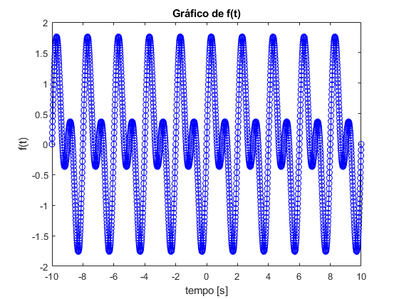

```matlab
t=-10:0.01:10;
disp('Dimensão do vetor tempo:')
disp(length(t))

f=sin(2*pi*t)+sin(pi*t);

plot(t,f,'-ob')
xlabel('tempo [s]')
ylabel('f(t)')
title('Gráfico de f(t)')
```

```
ft =
sin(pi*t) + sin(4*pi*t)
```

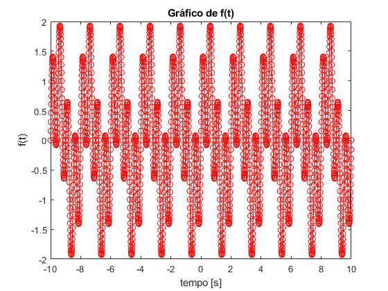

```matlab
syms t  % t=sym('t')
ft=sin(4*pi*t)+sin(pi*t)    % ft=sym('sin(4*pi*t)+sin(pi*t)')
t=-10:0.01:10;
f1=double(subs(ft));
plot(t,f1,'-or')
xlabel('tempo [s]')
ylabel('f(t)')
title('Gráfico de f(t)')
```

**Exercício 4.** Crie um script para representar graficamente a função $f(x,y) = \sin(x y) + \cos(x)$ recorrendo a cálculo numérico e a cálculo simbólico.

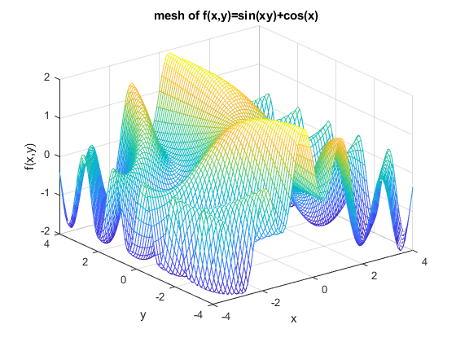

```matlab
x=-4:0.1:4;  % Definição do domínio de x e de y
y=-4:0.1:4;

[X,Y]=meshgrid(x,y);  % Produz as coordenadas duma grelha retangular (X, Y)

Z=sin(X.*Y)+cos(X);   % Calcula f(x,y)

mesh(X,Y,Z)           % Representação gráfica usando a função mesh
xlabel('x')
ylabel('y')
zlabel('f(x,y)')
title('mesh of f(x,y)=sin(xy)+cos(x)')
```

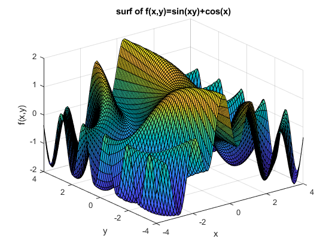

```matlab
surf(X,Y,Z)      % Representação gráfica usando a função surf
xlabel('x')
ylabel('y')
zlabel('f(x,y)')
title('surf of f(x,y)=sin(xy)+cos(x)')
```

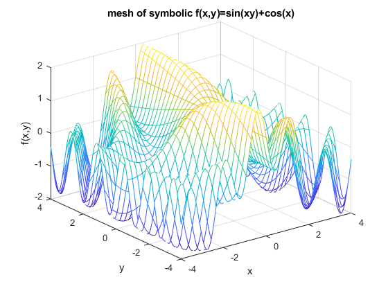

```matlab
syms x y                   % Define x e y como variávies simbólicas
fxy=sin(x*y)+cos(x);       % Calcula f(x,y) simbolicamente
fmesh(fxy,[-4 4 -4 4]);    % Representação gráfica usando a função fmesh
xlabel('x')
ylabel('y')
zlabel('f(x,y)')
title('mesh of symbolic f(x,y)=sin(xy)+cos(x)')
```

**Exercício 5.** Crie um script para encontrar os coeficientes de um polinómio de grau 2 que se ajusta a uma dada série temporal, pelo método dos mínimos quadrados, e para representar graficamente, no mesmo gráfico, os dados originais e o resultado do ajuste. Considere que a série temporal é definida para um intervalo de tempo de 0 a 10 segundos (passo de 1s) com os seguintes valores: $y = \begin{bmatrix} 0 & 0.7 & 2.4 & 3.1 & 4.2 & 4.8 & 5.7 & 5.9 & 6.2 & 6.4 & 6.3 \end{bmatrix} $.

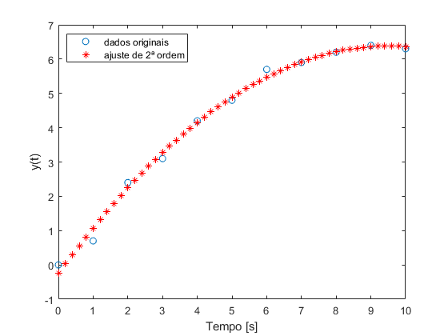

```matlab
t=0:10;                                        % intervalo temporal
y=[0 0.7 2.4 3.1 4.2 4.8 5.7 5.9 6.2 6.4 6.3]; % série temporal
p=polyfit(t,y,2);          % coeficientes do polinómo de 2º grau
t2=0:0.2:10;               % intervalo temporal com passo inferior
ye=polyval(p,t2);          % série temporal estimada

plot(t,y,'o',t2,ye,'*r')   % representação gráfica do resultado
xlabel('Tempo [s]')
ylabel('y(t)')
legend('dados originais','ajuste de 2ª ordem','Location','northwest')
```

**Exercício 6.** Desenvolva uma função não recursiva que calcule o fatorial de um número.

```matlab
%%file fatorial.m
function fact=fatorial(n)
fact=1;
for i=2:n
    fact=fact*i;
end
```

```
Created file 'C:\Users\Alberto Cardoso\Documents\Jupyter\ATD2021\FP1\fatorial.m'.
```

```matlab
%n=input('Número n: ');
n=11;              % número a considerar
fact=1;
for i=2:n          % cálculo do fatorial de forma não recursiva
    fact=fact*i;
end
disp(['Fatorial de ' num2str(n) ':'])
disp(fact)         % usando o resultado neste script
disp(fatorial(n))  % usando a função não recursiva
disp(factorial(n)) % usando a função do MATLAB
```

```
Fatorial de 11:
    39916800
    39916800
    39916800
```

**Exercício 7.** Desenvolva uma função não recursiva que calcule os primeiros N números da série de Fibonacci.

```matlab
%%file fib_series.m
function fib=fib_series(N)
if N==1
    fib(1)=0;
    return
else
    fib(1)=0;
    fib(2)=1;
    for i=3:N
        fib(i) = fib(i-1)+fib(i-2);
    end
end
```

```
Created file 'C:\Users\Alberto Cardoso\Documents\Jupyter\ATD2021\FP1\fib_series.m'.
```

```matlab
fib=fib_series(7)    % exemplo de cálculo dos primeiros números da série de Fibonacci
```

```
fib =
     0     1     1     2     3     5     8
```

**Exercício 8.** O modelo de Nicholson–Bailey foi criado para simular a coevolução de duas populações, uma de hospedeiros e outra de parasitas. O modelo é baseado em equações de diferença que descrevem o crescimento de ambas as populações. Mais concretamente, o modelo assume que os parasitas procuram hospedeiros de forma aleatória e que ambos (parasitas e hospedeiros) se encontram distribuídos de forma não contígua no espaço. Matematicamente o modelo é descrito por:

$H_{g+1}=kH_ge^{-aP_g}$

$P_{g+1}=cH_g(1-e^{-aP_g})$

Nas equações anteriores $H_g$ e $P_g$ representam o tamanho da população de hospedeiros e da população de parasitas na geração $g$, respetivamente, sendo $g$ definido de 0 a N. $k$ representa a taxa de reprodução dos hospedeiros, $c$ representa o número médio de ovos viáveis depositados pelos parasitas num único hospedeiro, e $a$ representa a probabilidade de um determinado parasita encontrar um hospedeiro durante a sua vida.

**8.1** Desenvolva uma função que permita simular a evolução de ambas as populações.

```matlab
%%file sim_evolucao.m
function [H,P]=sim_evolucao(a,k,c,N,H0,P0)
% a - probabilidade de um determinado parasita encontrar
%     um hospedeiro durante a sua vida
% k - taxa de reprodução dos hospedeiros
% c - número médio de ovos viáveis depositados pelos parasitas
%     num único hospedeiro
% N - número de gerações
% H0 - tamanho inicial da população de hospedeiros
% P0 - tamanho inicial da população de parasitas

H_g=H0;
P_g=P0;

H=H0;           % vetor da população de hospedeiros
P=P0;           % vetor da população de parasitas

for i = 1:N,    % simulação do modelo
    H_g_1 = k*H_g*exp(-a*P_g);
    P_g_1 = c*H_g*(1-exp(-a*P_g));
    H_g = H_g_1;
    P_g = P_g_1;
    H=[H H_g];
    P=[P P_g];
end
```

```
Created file 'C:\Users\Alberto Cardoso\Documents\Jupyter\ATD2021\FP1\sim_evolucao.m'.
```

**8.2** Desenvolva também um script que chame a função desenvolvida e represente graficamente a evolução de ambas as populações, considerando, por exemplo, os seguintes casos:

**8.2.1** $a=0.025; k=1.0; c=2; N=30; H_0=20; P_0=10$

**8.2.2** $a=0.025; k=1.5; c=2; N=30; H_0=20; P_0=10$

**8.2.3** $a=0.025; k=1.5; c=2; N=30; H_0=15; P_0=10$

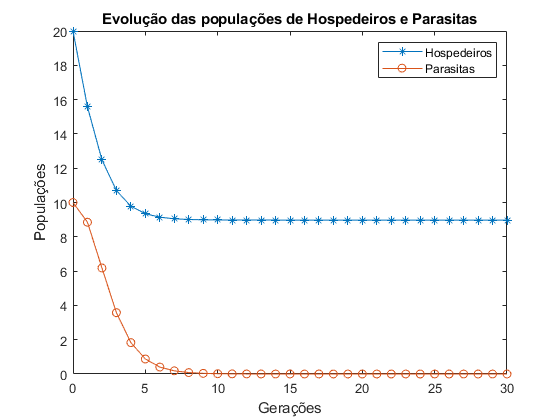

```matlab
N=30;     % número de gerações
[H,P]=sim_evolucao(0.025,1.0,2,N,20,10);  % 8.2.1
plot(0:N,H,'-*',0:N,P,'-o')
xlabel('Gerações')
ylabel('Populações')
title('Evolução das populações de Hospedeiros e Parasitas')
legend('Hospedeiros','Parasitas')
```

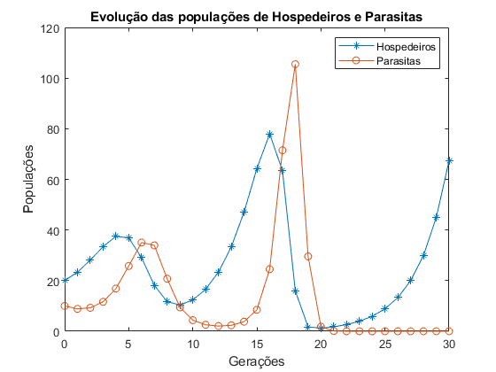

```matlab
N=30;     % número de gerações
[H,P]=sim_evolucao(0.025,1.5,2,N,20,10);  % 8.2.2
plot(0:N,H,'-*',0:N,P,'-o')
xlabel('Gerações')
ylabel('Populações')
title('Evolução das populações de Hospedeiros e Parasitas')
legend('Hospedeiros','Parasitas')
```

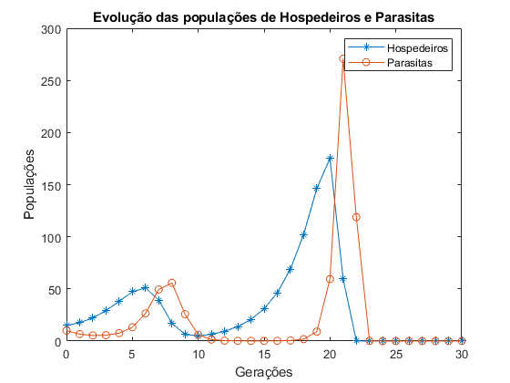

```matlab
N=30;     % número de gerações
[H,P]=sim_evolucao(0.025,1.5,2,N,15,10);  % 8.2.3
plot(0:N,H,'-*',0:N,P,'-o')
xlabel('Gerações')
ylabel('Populações')
title('Evolução das populações de Hospedeiros e Parasitas')
legend('Hospedeiros','Parasitas')
```